# Pricing Asian Options

By Jovan Allan, Joseph Leong

## What Is an Asian Option?

Also known as an Average Price Option

There are many variations of asian optioins, we will be looking at this particular example where

the payoff for asian call option is

$$ C_a = Max\left(\frac{1}{n} \sum_{i=1}^{n} S_d(i) - K,0\right) $$

Compared to European Call

$$ C_e = Max\left(S(t) - K,0\right) $$

Advantages

- Reduces the risk of Market manipulation
- Less Volatile than European options

## Monte Carlo Simulation

This is a statistical technique used to model probabalistic events.

Idea:

- generate many values of outputs from a predefined range of inputs
- aggregate the outputs to get a sample average.
- sample average will converge to expected value as # of outputs increase
- sample average will have an approximatly Normal Distribution as # of outputs increases

Applying this idea to Asian Option Prices

First, generate daily asian share prices using Risk-Neutral GBM model $$ {S_d(0),S_d(1),...S_d(n)} $$

Second, calculate the present value of the Asian Option Payoff

$$ Y=e^{\frac{-rn}{N}} \left( \sum_{i}^{n} \frac{S_d(i)}{n} -K \right)^{+} $$

Third, Repeat to generate $k-1$ more simulations so that in total there are $k$ simulated Asian Option payoffs

$$ Y_1,Y_2...Y_k $$

Last, average of $k$ simulated Asian Option payoffs will yields the estimate of the Risk-Neutral valuation of the call. $$ \sum_{i}^{k} \frac{Y_i}{k} \rightarrow e^{\frac{-rn}{N}}E_{RN} \left(Payoff \right) $$

## MONTECARLO SIMULATION Code

using the following parameters

s = 61 d = 126 (1/2 year) K = 63 r = 0.08 $\sigma$ = 0.3

```r
#Variable Selection
share = 61
day = 126
strike = 63
rate = 0.08
sigma = 0.3
```

```r
#Creates a matrix of n simulations of stock realizations
asianOptions=function(s,D,K,r,sd,n) {
    xd=matrix(c(rnorm((D)*n,(r-(sd^2/2))/252,sd/sqrt(252))),n,D)
    sd=s*exp(t(apply(xd,1,cumsum)))
    avg=apply(sd,1,mean)
    callpv=pmax(avg-K,0)*exp(-r*D/252)
    return(mean(callpv))
}

asianOptions.V=function(s,D,K,r,sd,n) {
    xd=matrix(c(rnorm((D)*n,(r-(sd^2/2))/252,sd/sqrt(252))),n,D)
    sd=s*exp(t(apply(xd,1,cumsum)))
    avg=apply(sd,1,mean)
    callpv=pmax(avg-K,0)*exp(-r*D/252)
    return(var(callpv))
}

#Create Euro Call option
euroOption=function(s,K,r,sd,t) {
  w=((r+sd^2/2)*t/252-log(K/s))/(sd*sqrt(t/252))
  c=s*pnorm(w)-K*exp(-r*t/252)*pnorm(w-sd*sqrt(t/252))
  return(c)
}
```

## How Does Asian Option Compare to Euro Option?

```r
x=0;for(i in 1:1000) {
  x=x+asianOptions(share,day,strike,rate,sigma,1000)
}
print(x/1000)
```

```
[1] 2.626515
```

Compare to European option price?

```r
euroOption(share,strike,rate,sigma,day)
```

5.37134528172943

## Visulization of Asian Option

```r
realization = function(s,D,K,r,sd,n){
    xd=matrix(c(rnorm((D)*n,(r-(sd^2/2))/252,sd/sqrt(252))),n,D)
    sd=s*exp(t(apply(xd,1,cumsum)))
    return(sd)
}
```

```
[1] "Average Stock Price"
```

66.1635730426605

```
[1] "Payoff of Asian Option"
```

3.03952756937519

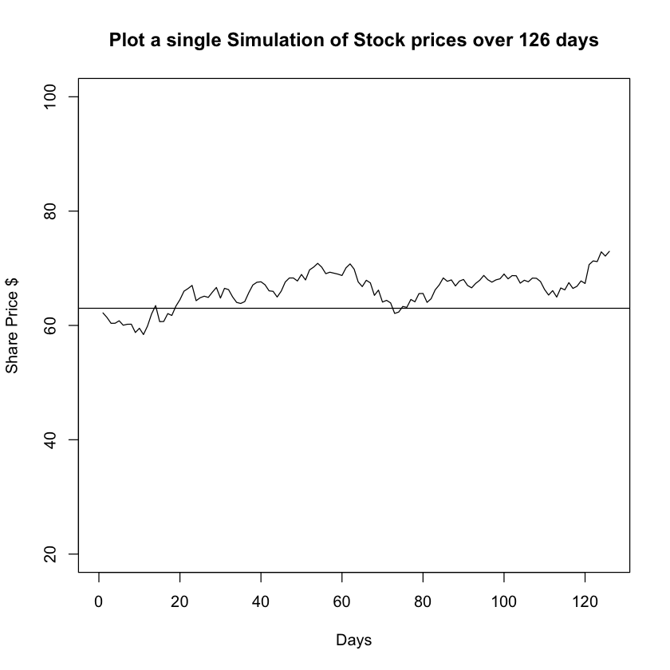

```r
x = seq(1:126)
y = realization(share,day,strike,rate,sigma,10)
plot(x,y[1,], main = "Plot a single Simulation of Stock prices over 126 days",
     xlab = "Days",
     ylab = "Share Price $",
     xlim = c(0,126),
     ylim=c(20,100),
     type = 'l')
abline(h=strike)
print("Average Stock Price")
mean(y[1,])
print("Payoff of Asian Option")
max((mean(y[1,]) - strike),0)*exp(-rate*day/252)
```

```
[1] "Average Stock Price"
```

1. 66.1635730426605

2. 64.7027101012699

3. 65.0614325373428

4. 74.4280104141445

5. 60.0866543796086

6. 66.5024792453617

7. 64.7272195595935

8. 48.2245928004413

9. 59.8177080588912

10. 58.1886026979329

```
[1] "Payoff of Asian Option"
```

2.26606271621985

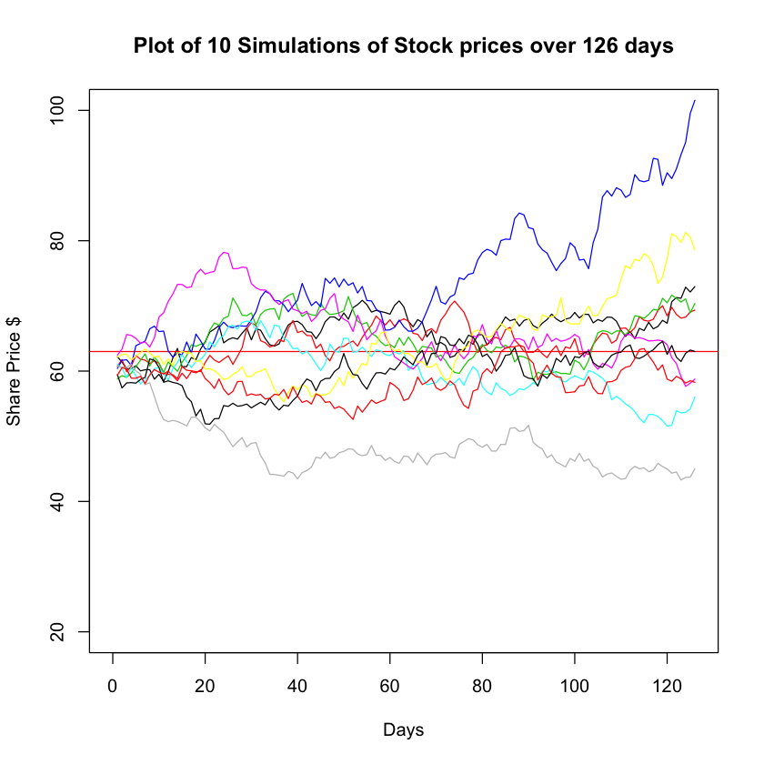

```r
plot(x,y[1,], main = "Plot of 10 Simulations of Stock prices over 126 days",
     xlab = "Days",
     ylab = "Share Price $",
     xlim = c(0,126),
     ylim=c(20,100),
     type = 'l')
abline(h= strike, col='red' )
for( i in 2:10){
    lines(x,y[i,], col = i)
}
avg=apply(y,1,mean)

print("Average Stock Price")
avg
print("Payoff of Asian Option")
mean(pmax((avg - strike),0)*exp(-rate*day/252))
```

## Expected Value and Variance

```r
numofsim = 100
for(i in 1:10){
    print(c(asianOptions(share,day,strike,rate,sigma,numofsim),asianOptions.V(share,day,strike,rate,sigma,numofsim)))
    }
```

```
[1]  2.612068 28.534359
[1]  2.896276 26.756216
[1]  2.15570 18.95884
[1]  1.837812 25.745627
[1]  3.279394 21.071770
[1]  2.401967 26.215206
[1]  3.635624 14.438151
[1]  2.838711 22.412249
[1]  2.791585 18.892563
[1]  2.984013 17.974606
```

n = 1000000 [1] 2.632722 20.175960 [1] 2.629572 20.107152 [1] 2.617941 19.956537 [1] 2.625505 20.098192 [1] 2.624909 20.016488 [1] 2.615629 19.977494 [1] 2.628922 20.132319 [1] 2.619424 20.036418 [1] 2.623533 20.027172 [1] 2.632191 20.116323

n = 10000000 [1] 2.623967 20.082084 [1] 2.625328 20.081116 [1] 2.622219 20.046961 [1] 2.623188 20.043647 [1] 2.622652 20.065704 [1] 2.625139 20.087812 [1] 2.622739 20.044615 [1] 2.623389 20.073185 [1] 2.624379 20.077573 [1] 2.625775 20.083400

To be accurate within 0.01 cent

$$ 0.01<\sqrt{VAR(\bar{Y}}) = \sqrt{\frac{VAR(Y)}{k}} $$

Since $VAR(Y)$ is unknown, use the sample variance $\widehat{VAR(Y)}$ instead

$$ \begin{align} 0.01 &< \sqrt{\frac{\widehat{VAR(Y)}}{k}} \\ k &< \frac{\widehat{VAR(Y)}}{0.01^2} \\ &< \frac{(\approx 20)}{0.01^2} \\ &< 200000 \end{align} $$

## How does the parameters affect the cost of asian option?

[figure not shown]

- Convex in s and K

## Discussion

- Slow due to need to simulated lot of realizations
- Probabalistic results as oppose to determinstic